# VAR Model Analysis on Personal Savings Rate and Industry Production of Manufacturing

William Stevenson

04-22-2022

$~$

## Abstract

This analysis will take a look at Personal Savings rate in the United States as well as Industry Production of Manufacturing to see how much each variable helps in predicting the other. The impulse response functions produced in this analysis found that shocks to Manufacturing Production percentage change did induce a response in Personal Savings Rate percentage change and that shocks to Personal Savings Rate percentage change had an impact on the percentage change of Manufacturing Production. The conclusion drawn from this is that when Manufacturing Production spikes, people adjust their savings rate quickly. On the other side of the coin, the percentage change of Manufacturing Production is also affected by the savings habits of the general population. However, the later is a weaker relationship than the former. To see the entire code and html file, follow this link. [link](https://will-stevenson813.github.io)

### Unit Root Tests

The first thing that needs to be done is to look at our data to determine if we should be using either a VAR model or VECM (Vector-Error-Correction). One major distinction between the models is that VAR models will only work on stationary data. The Dickey-Fuller unit root tests were employed below and returned very significant p-values. As the null hypothesis for the Dickey-Fuller Unit root test is that their is no stationarity, we reject that null hypothesis and confirm that these variables are stationary. We can continue with our VAR model.

```r
ur.IPMAN <- ur.df(D$IPMAN, type = "drift", selectlags = "BIC")
URIP <- summary(ur.IPMAN)

URIP@testreg$coefficients[2,] %>%
    kable(format = "html", table.attr = "style='width:30%;' ", caption = "Manufacturing Production UR Test") %>%
  kableExtra::kable_styling()
```

Manufacturing Production UR Test

|  | x |
| --- | --- |
| Estimate | -0.759849 |
| Std. Error | 0.050319 |
| t value | -15.100652 |
| Pr(>\|t\|) | 0.000000 |

```r
ur.PSR <- ur.df(D$PSR, type = "drift", selectlags = "BIC")

URPSR <- summary(ur.PSR)

URPSR@testreg$coefficients[2,] %>%
    kable(format = "html", table.attr = "style='width:30%;' ", caption = "Personal Savings UR Test")%>%
  kableExtra::kable_styling()
```

Personal Savings UR Test

|  | x |
| --- | --- |
| Estimate | -1.2918343 |
| Std. Error | 0.0627432 |
| t value | -20.5892468 |
| Pr(>\|t\|) | 0.0000000 |

### Estimating Model

Below are the outputs of the estimation of our VAR model. The reported F-Statistics reveal that indeed both Personal Savings Rate as well as Manufacturing Production are useful in predicting each other. These findings are congruent with our hypothesis that spikes in Manufacturing production do have in influence in the rate at which people save their income. It is also true that the rate at which citizens save their income is also useful in predicting changes in Manufacturing production. It is important to notice that the higher F-Stat for the second table provides evidence for the fact that IPMAN has a greater influence over Personal Savings rate than Personal Savings rate has over IPMAN. Next, the impulse response graphs as well as the forecast error variance decomposition are posted below to help visualize this relationship.

```r
PSRIPMAN <- grangertest(IPMAN ~ PSR,order=p,data=Dts)



IPMANPSR <- grangertest(PSR ~ IPMAN,order=p,data=Dts)

PSRIPMAN
```

|  | Res.Df | Df | F | Pr(>F) |
| --- | --- | --- | --- | --- |
| 1 | 594 | NA | NA | NA |
| 2 | 596 | -2 | 6.028337 | 0.002559425 |

```r
IPMANPSR
```

|  | Res.Df | Df | F | Pr(>F) |
| --- | --- | --- | --- | --- |
| 1 | 594 | NA | NA | NA |
| 2 | 596 | -2 | 11.9457 | 8.197222e-06 |

### Impulse Response Graphs

Below are the two charts that follow the responses of both variables when a ‘ping’ of one standard deviation is applied to the original state. The first figure shows a one standard deviation shock to Personal Savings rate and the response from IPMAN below that. The second figure shows a one standard deviation shock to IPMAN and the response from Personal Savings rate above that. The first figure confirms that shocks to Personal Savings rate do have a marginal (but statistically significant) effect on the percentage change in Manufacturing production. One month after the shock to Personal Savings, the 95% confidence interval (the red-dashed lines on either side of the trend) does fall below the original state for a brief time. The second figure confirms our findings that a one standard deviation positive shock to IPMAN does have a much larger effect on the Personal Savings rate.

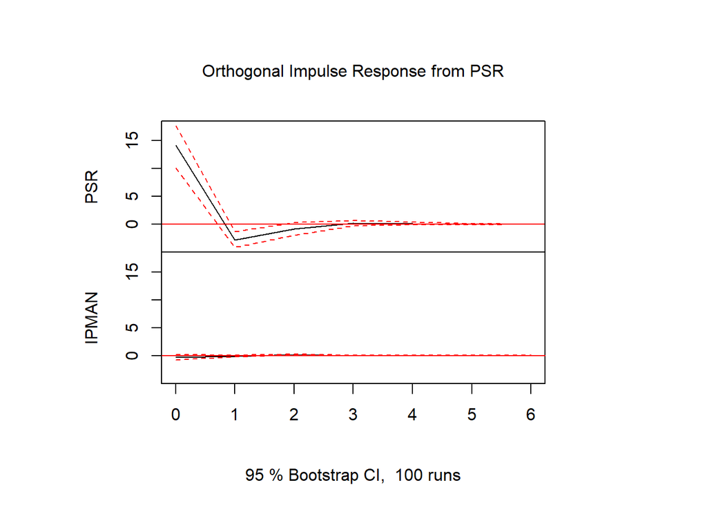

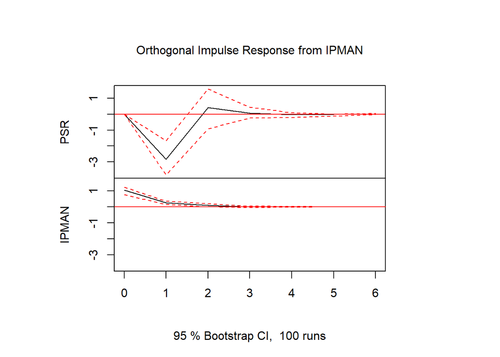

```r
plot(irf(var.D, n.ahead = 6, boot = TRUE ))
```

### FEVD Output

The output from our Forecast-Error-Variance-Decomposition shows the amount of variance explained by each of the the variables for a forecast period of 1 year. The top figure explains that virtually all of the variance in the forecasts for Personal Savings rate is explained by its own variance while only a small portion is explained by the variance in IPMAN. The next figure shows practically the same situation for IPMAN. Most of IPMAN’s variance of the 1 year forecast is explained by its own variance with only a small proportion coming from the variance of Personal Savings rate. The constant ratio implies that the amount of variance explained by the other variable does not change very much if at all over time.

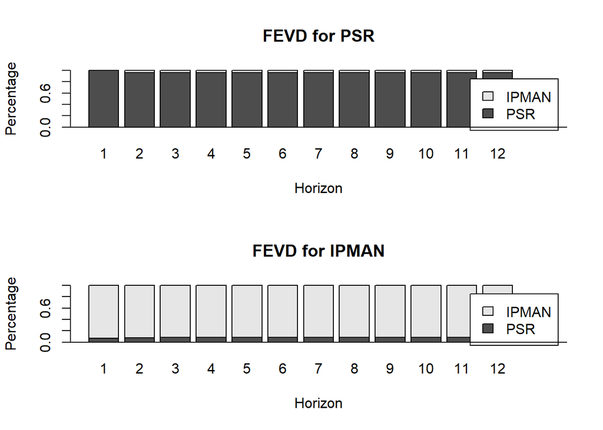

```r
plot(fevd(var.D, n.ahead = 12))
```

### Inversing the Shock to IPMAN

A curiosity came up when doing our analysis about how Personal Savings rate would respond to negative shocks to IPMAN and whether or not those dynamics look any different from positive shocks. The intuition behind this is that individuals perhaps are more likely to increase consumption (lower savings rate) faster than they are willing to reduce consumption. In order to explore this theory, we had to reverse the direction of the of the shock to IPMAN. The figure below shows that the response from Personal Savings rate is practically the same just in the inverse direction. As it turns out, individuals respond very similarly to positive and negative shocks to Manufacturing production just in inverse ways.

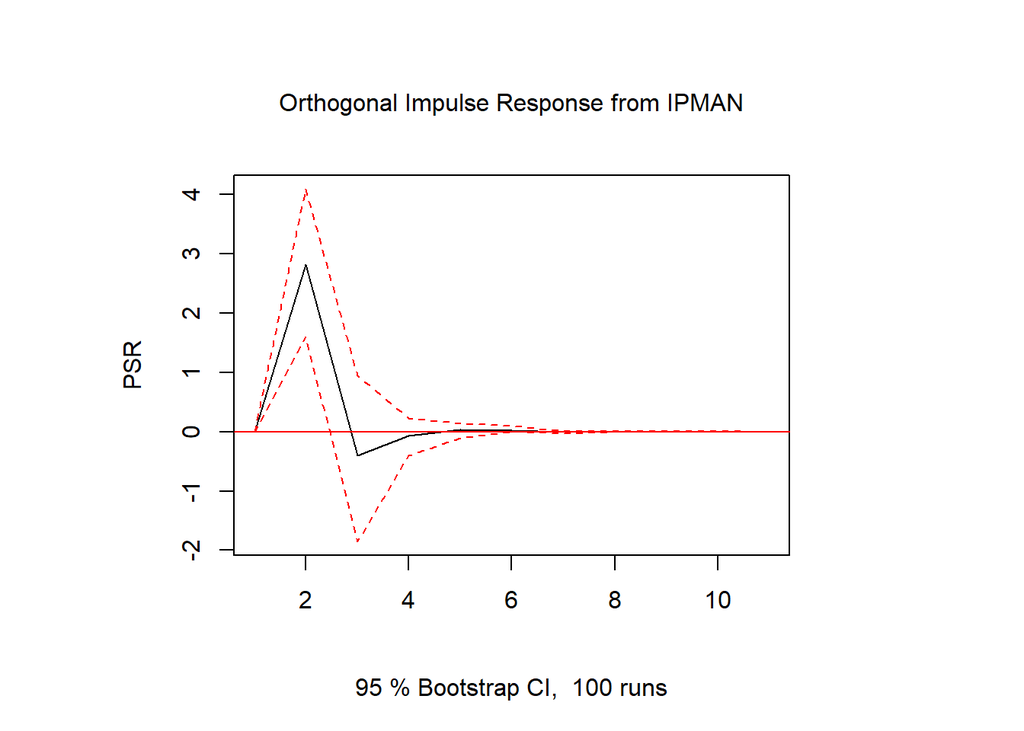

```r
var.2c=VAR(Dts,p=p,type="const")

irf.rw.e=irf(var.2c,impulse="IPMAN",response=c("PSR"))

gamma=-1

irf.rw.e_gamma = irf.rw.e

n=length(irf.rw.e_gamma$irf$IPMAN)

for(i in 1:n){
    irf.rw.e_gamma$irf$IPMAN[i]   = irf.rw.e_gamma$irf$IPMAN[i]*gamma
    irf.rw.e_gamma$Lower$IPMAN[i] = irf.rw.e_gamma$Lower$IPMAN[i]*gamma
    irf.rw.e_gamma$Upper$IPMAN[i] = irf.rw.e_gamma$Upper$IPMAN[i]*gamma
}


plot(irf.rw.e_gamma)
```

### Conclusion

The findings from our analysis confirm our suspicions that core economic health indicators (Manufacturing Production) are useful in predicting the Personal Savings rate. What we did not expect to find was that Personal Savings rate did have a statistically significant effect on predicting Manufacturing production, however to a much smaller degree. We also found that individuals respond to shocks in the Manufacturing production in relatively the same manner just inversely. This analysis cannot comment on the mechanism behind these influences, but our intuition and economic theory leads us to believe that positive shocks in Manufacturing production induce individuals to increase consumption and decrease savings. It does not seem that individuals would save more to invest in these companies and increase future earnings. To the contrary, negative shocks to Manufacturing production signal to consumers that potential economic downturn is imminent and that they should save more of their income.